# Comparisons between TEgenomeSimulator, denovoTE-eval, and Garlic

### 2.03c Superfamily-composition JSD: bar plots (mean ± SD, asterisk if p < 0.001)

#### Plot 1: dnvTEe vs TEGS (one-sample test per metric, asterisk above each bar)

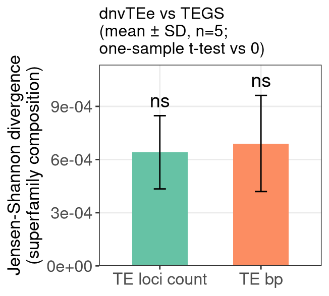

#### Plots 2 & 3: GARLIC/m2/m2+m0 vs Ori (pairwise unpaired tests, asterisk on brackets)

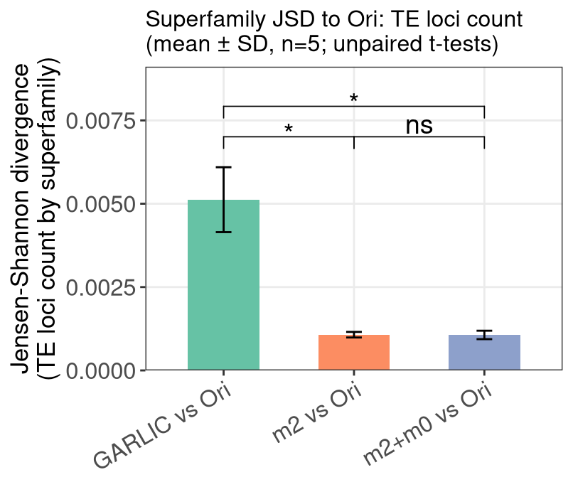

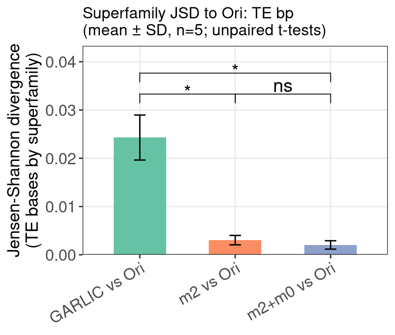

### 2.04 The distribution of TE loci divergence

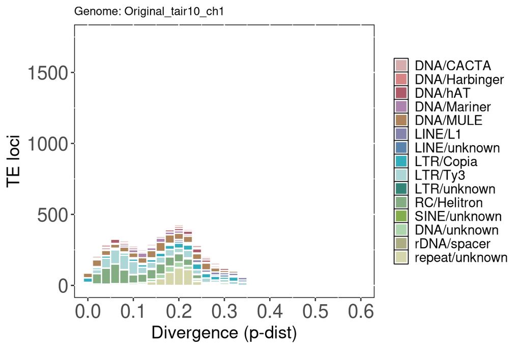

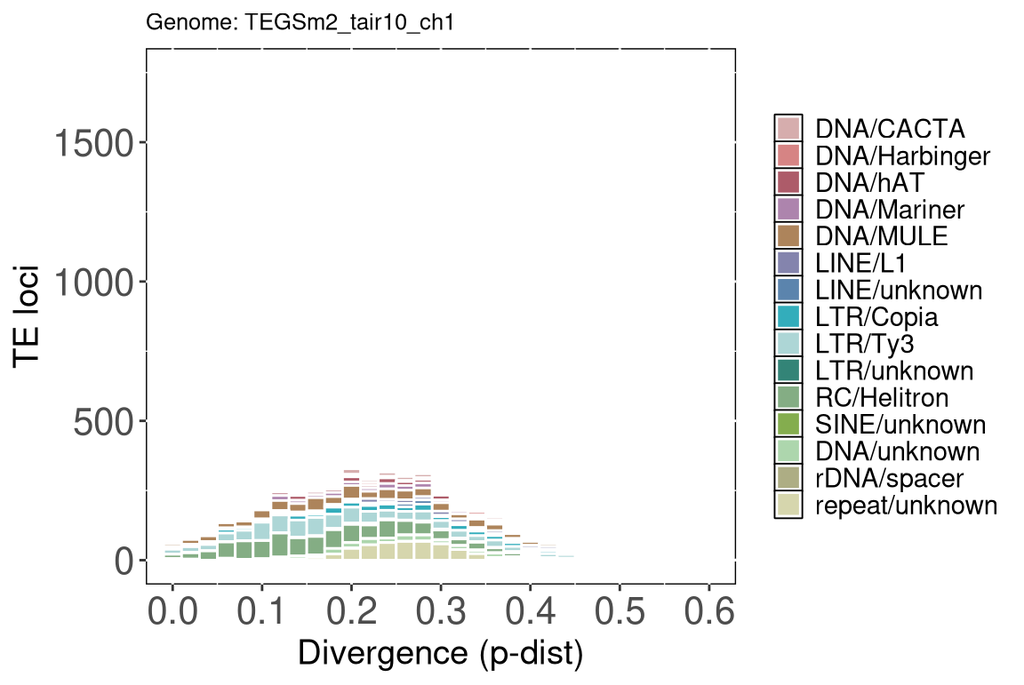

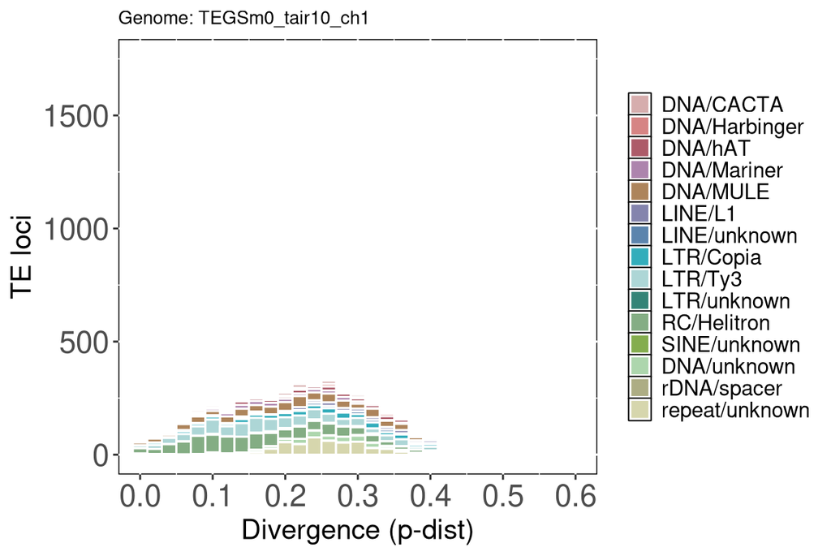

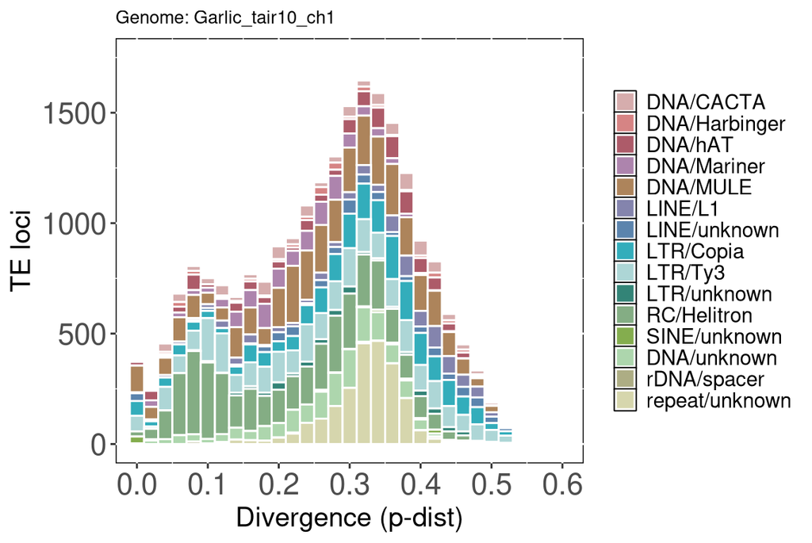

#### Mean ± SD across replicates (superfamilies pooled; Ori not replicated)

Bin mean/SD are extracted via `ggplot_build()` from per-replicate histograms built purely for that purpose (not displayed) - same approach as section 1, so the line graph’s bins always match what a histogram of the same data would show. Ori has only one genome, so its line has no ribbon (SD is undefined for n=1).

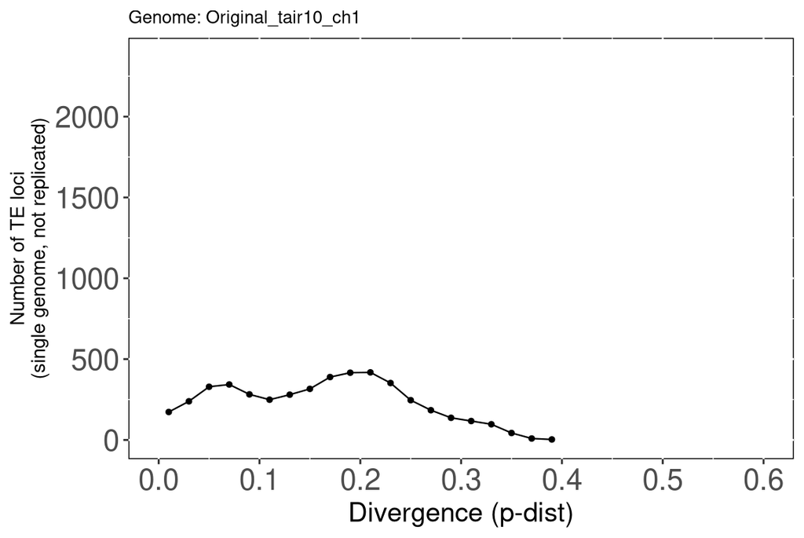

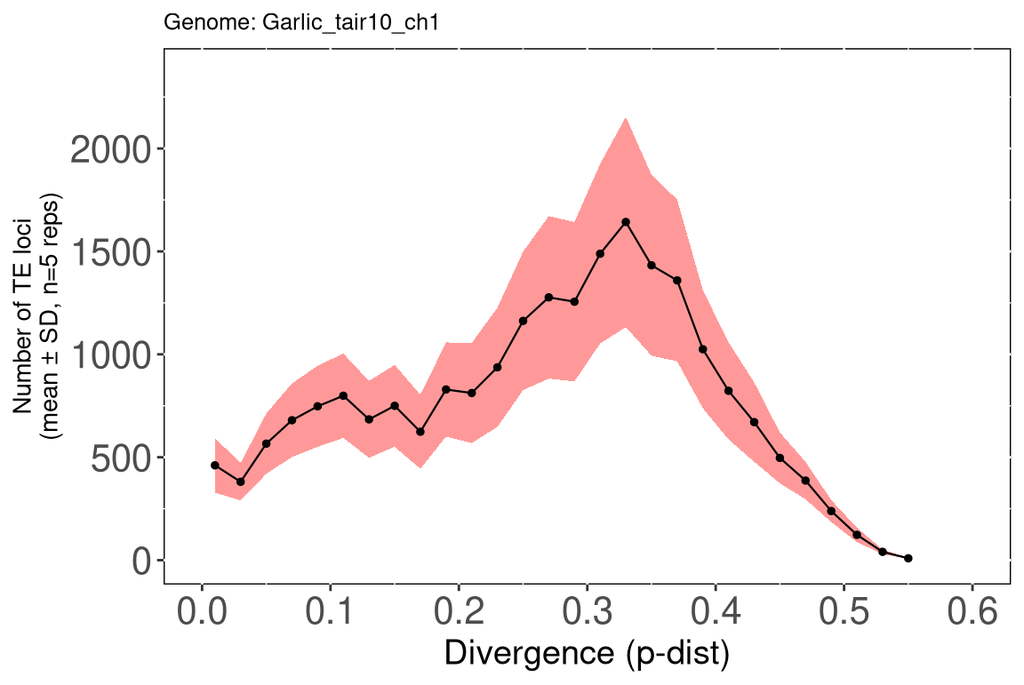

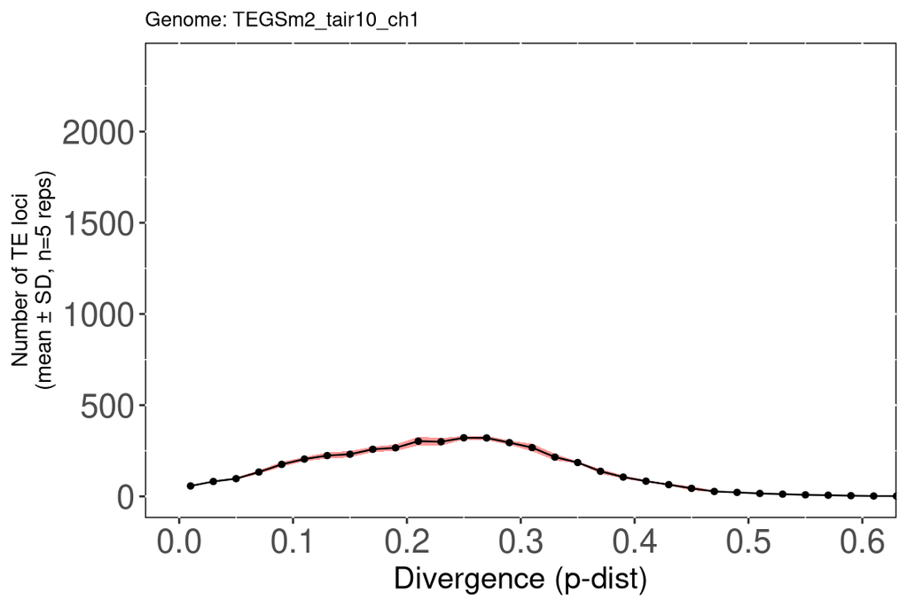

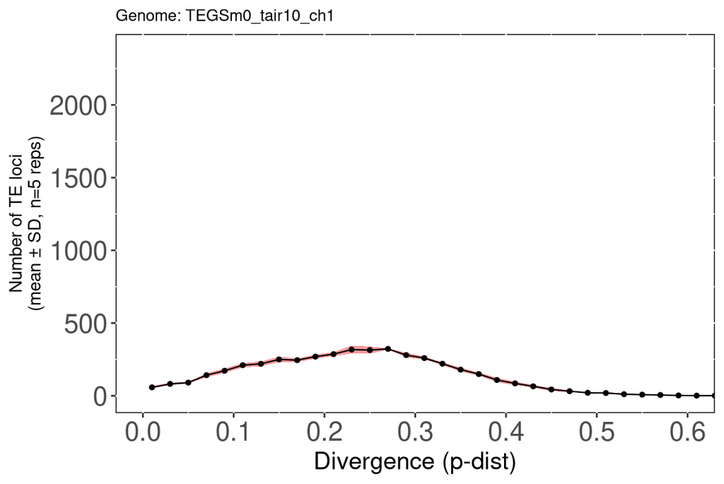

### 2.05 The distribution of TE loci integrity

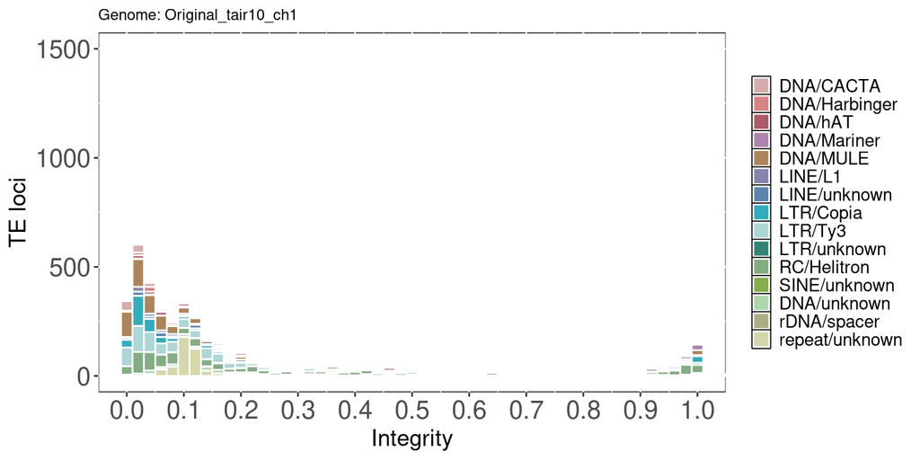

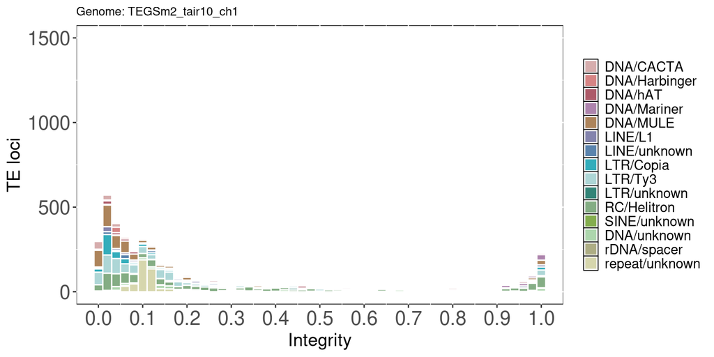

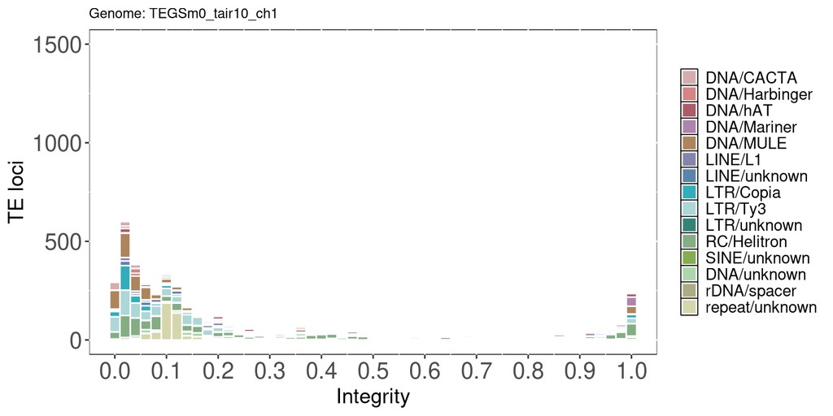

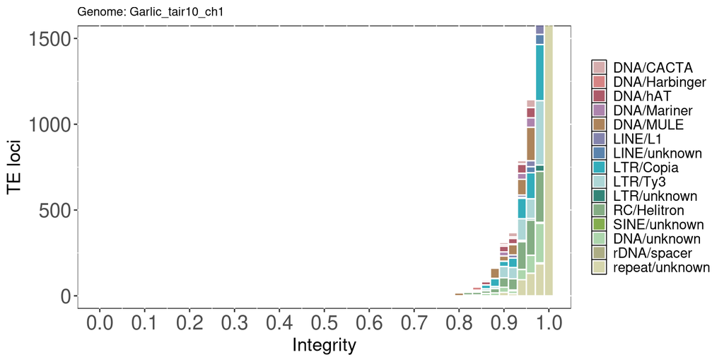

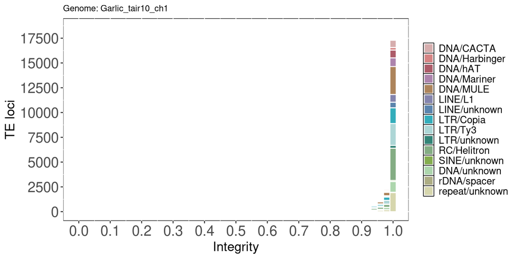

#### Mean ± SD across replicates (superfamilies pooled; Ori not replicated)

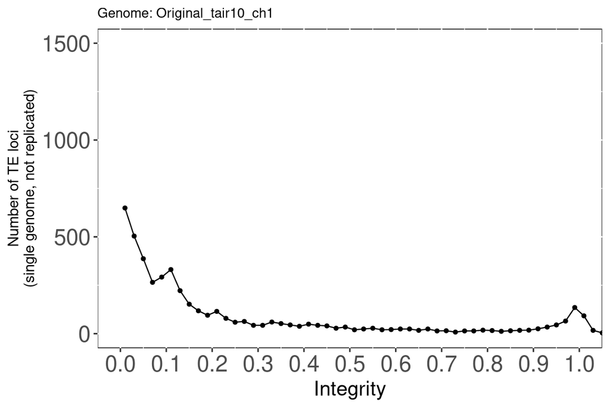

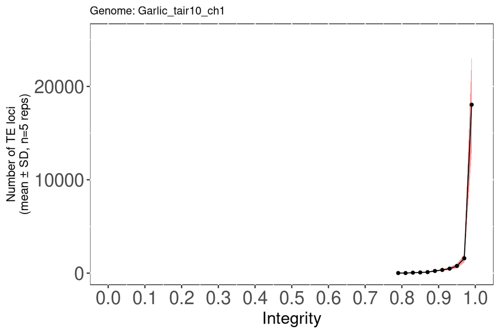

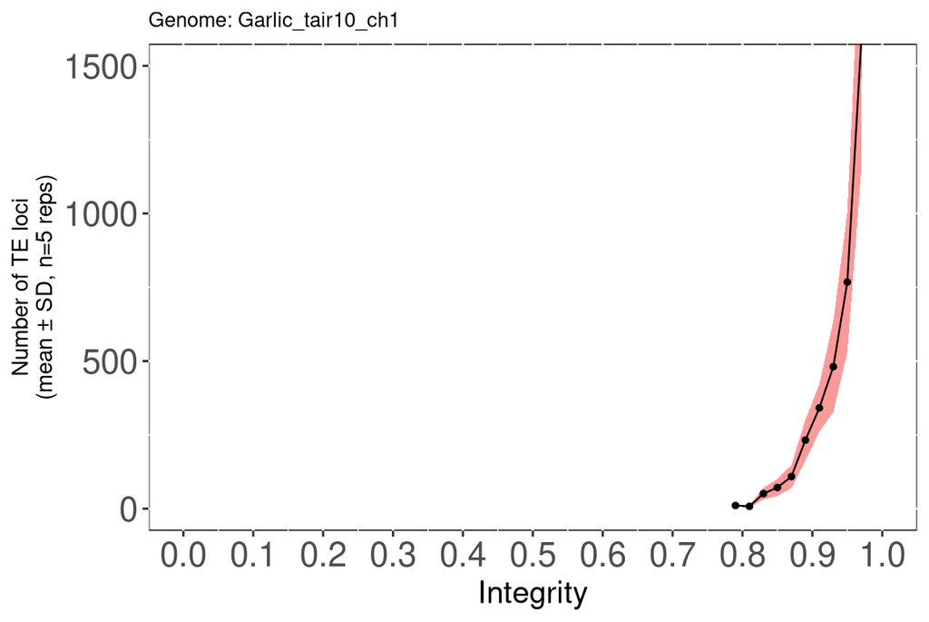

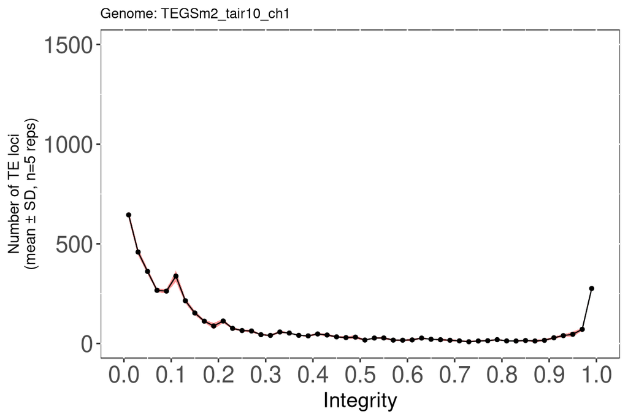

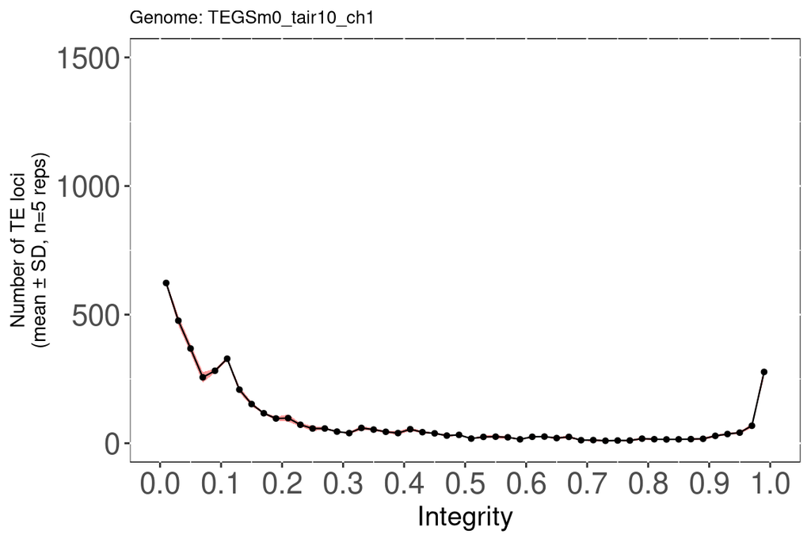

### 2.05a Wasserstein distance: TE loci divergence and integrity (per replicate)

1D (earth-mover’s) Wasserstein distance between raw per-locus divergence (`div`) and integrity (`itg`) values (superfamilies pooled, as in Fig. 2’s mean ± SD panels above), computed per replicate using the same `breakdown*_allreps` tables built earlier in this notebook. Unlike JSD (Point 1), Wasserstein operates directly on the continuous raw values rather than a binned/categorical distribution, so no bin-width choice is involved. dnvTEe vs TEGS is paired by replicate index (rep i’s dnvTEe run reuses rep i’s TEGS composition table); Garlic/m2/m2+m0 vs Ori compares each replicate against Ori’s single fixed distribution (`breakdown0_allreps`, not replicated).

| comparison | rep | metric | wasserstein |
| --- | --- | --- | --- |
| dnvTEe vs TEGS | 1 | div | 0.0011 |
| dnvTEe vs TEGS | 2 | div | 0.0015 |
| dnvTEe vs TEGS | 3 | div | 0.0040 |
| dnvTEe vs TEGS | 4 | div | 0.0020 |
| dnvTEe vs TEGS | 5 | div | 0.0020 |
| GARLIC vs Ori | 1 | div | 0.1062 |
| GARLIC vs Ori | 2 | div | 0.1053 |
| GARLIC vs Ori | 3 | div | 0.1030 |
| GARLIC vs Ori | 4 | div | 0.1056 |
| GARLIC vs Ori | 5 | div | 0.1053 |
| m2 vs Ori | 1 | div | 0.0680 |
| m2 vs Ori | 2 | div | 0.0697 |
| m2 vs Ori | 3 | div | 0.0698 |
| m2 vs Ori | 4 | div | 0.0699 |
| m2 vs Ori | 5 | div | 0.0690 |
| m2+m0 vs Ori | 1 | div | 0.0681 |
| m2+m0 vs Ori | 2 | div | 0.0678 |
| m2+m0 vs Ori | 3 | div | 0.0703 |
| m2+m0 vs Ori | 4 | div | 0.0698 |
| m2+m0 vs Ori | 5 | div | 0.0694 |
| dnvTEe vs TEGS | 1 | itg | 0.2326 |
| dnvTEe vs TEGS | 2 | itg | 0.2331 |
| dnvTEe vs TEGS | 3 | itg | 0.2334 |
| dnvTEe vs TEGS | 4 | itg | 0.2289 |
| dnvTEe vs TEGS | 5 | itg | 0.2325 |
| GARLIC vs Ori | 1 | itg | 0.7419 |
| GARLIC vs Ori | 2 | itg | 0.7420 |
| GARLIC vs Ori | 3 | itg | 0.7425 |
| GARLIC vs Ori | 4 | itg | 0.7420 |
| GARLIC vs Ori | 5 | itg | 0.7420 |
| m2 vs Ori | 1 | itg | 0.0093 |
| m2 vs Ori | 2 | itg | 0.0063 |
| m2 vs Ori | 3 | itg | 0.0070 |
| m2 vs Ori | 4 | itg | 0.0068 |
| m2 vs Ori | 5 | itg | 0.0070 |
| m2+m0 vs Ori | 1 | itg | 0.0083 |
| m2+m0 vs Ori | 2 | itg | 0.0115 |
| m2+m0 vs Ori | 3 | itg | 0.0055 |
| m2+m0 vs Ori | 4 | itg | 0.0101 |
| m2+m0 vs Ori | 5 | itg | 0.0051 |

File saved as: wasserstein_divergence_integrity_per_replicate.tsv (columns: comparison, rep, metric [“div”/“itg”], wasserstein)

### 2.05b Wasserstein distance: mean ± SD and significance testing

Same design as the superfamily-JSD testing in 2.03b, applied to the Wasserstein distances: dnvTEe vs TEGS is matched-pair by construction, so its 5 distance values are tested with a one-sample t-test against mu = 0. Garlic/m2/m2+m0 replicates were each generated independently of one another, so their distance-to-Ori values are compared pairwise with unpaired (two-sample Welch) t-tests. Reuses `tidy_ttest_dist()` defined in section 2.03b.

| comparison | metric | n | mean_wasserstein | sd_wasserstein |
| --- | --- | --- | --- | --- |
| GARLIC vs Ori | div | 5 | 0.1051 | 0.0012 |
| GARLIC vs Ori | itg | 5 | 0.7421 | 0.0003 |
| dnvTEe vs TEGS | div | 5 | 0.0021 | 0.0011 |
| dnvTEe vs TEGS | itg | 5 | 0.2321 | 0.0018 |
| m2 vs Ori | div | 5 | 0.0693 | 0.0008 |
| m2 vs Ori | itg | 5 | 0.0073 | 0.0012 |
| m2+m0 vs Ori | div | 5 | 0.0691 | 0.0011 |
| m2+m0 vs Ori | itg | 5 | 0.0081 | 0.0028 |

| comparison | test_type | n1 | n2 | mean1 | mean2 | reference | mean_diff | t_statistic | df | p_value | conf_low | conf_high | alternative | metric | group1 | group2 |
| --- | --- | --- | --- | --- | --- | --- | --- | --- | --- | --- | --- | --- | --- | --- | --- | --- |
| dnvTEe vs TEGS (Wasserstein, div) | one-sample t-test (vs mu) | 5 | NA | 0.0021 | NA | 0 | 0.0021 | 4.1796 | 4.0000 | 0.0139 | 0.0007 | 0.0035 | two.sided | div | dnvTEe vs TEGS | NA |
| GARLIC vs m2 (distance-to-Ori Wasserstein, div) | two-sample t-test (Welch, unpaired) | 5 | 5 | 0.1051 | 0.0693 | NA | 0.0358 | 54.7995 | 6.8060 | 0.0000 | 0.0342 | 0.0373 | two.sided | div | GARLIC vs Ori | m2 vs Ori |
| GARLIC vs m2+m0 (distance-to-Ori Wasserstein, div) | two-sample t-test (Welch, unpaired) | 5 | 5 | 0.1051 | 0.0691 | NA | 0.0360 | 48.8691 | 7.8916 | 0.0000 | 0.0343 | 0.0377 | two.sided | div | GARLIC vs Ori | m2+m0 vs Ori |
| m2 vs m2+m0 (distance-to-Ori Wasserstein, div) | two-sample t-test (Welch, unpaired) | 5 | 5 | 0.0693 | 0.0691 | NA | 0.0002 | 0.2961 | 7.2686 | 0.7754 | -0.0012 | 0.0016 | two.sided | div | m2 vs Ori | m2+m0 vs Ori |
| dnvTEe vs TEGS (Wasserstein, itg) | one-sample t-test (vs mu) | 5 | NA | 0.2321 | NA | 0 | 0.2321 | 286.3145 | 4.0000 | 0.0000 | 0.2299 | 0.2344 | two.sided | itg | dnvTEe vs TEGS | NA |
| GARLIC vs m2 (distance-to-Ori Wasserstein, itg) | two-sample t-test (Welch, unpaired) | 5 | 5 | 0.7421 | 0.0073 | NA | 0.7348 | 1394.3598 | 4.3863 | 0.0000 | 0.7334 | 0.7362 | two.sided | itg | GARLIC vs Ori | m2 vs Ori |
| GARLIC vs m2+m0 (distance-to-Ori Wasserstein, itg) | two-sample t-test (Welch, unpaired) | 5 | 5 | 0.7421 | 0.0081 | NA | 0.7340 | 582.7530 | 4.0652 | 0.0000 | 0.7305 | 0.7375 | two.sided | itg | GARLIC vs Ori | m2+m0 vs Ori |
| m2 vs m2+m0 (distance-to-Ori Wasserstein, itg) | two-sample t-test (Welch, unpaired) | 5 | 5 | 0.0073 | 0.0081 | NA | -0.0009 | -0.6278 | 5.3097 | 0.5561 | -0.0043 | 0.0026 | two.sided | itg | m2 vs Ori | m2+m0 vs Ori |

Files saved as: wasserstein_meansd.tsv, wasserstein_ttest.tsv

### 2.05c Wasserstein distance: bar plots (mean ± SD, asterisk if p < 0.001)

Same layout as the superfamily-JSD bar plots in 2.03c. Reuses `sig_asterisk()` defined there.

#### Plot 1: dnvTEe vs TEGS (one-sample test per metric, asterisk above each bar)

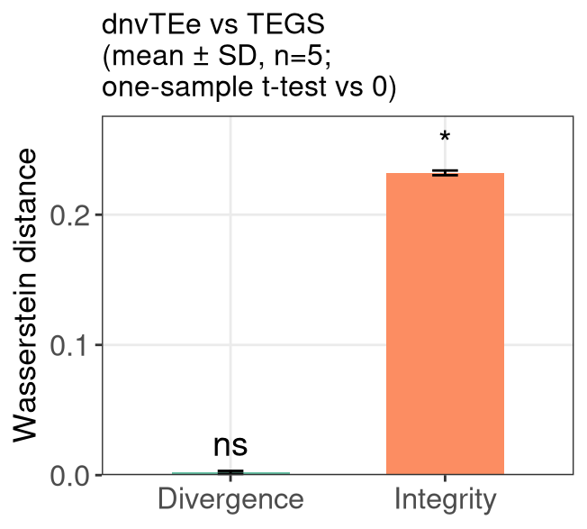

#### Plots 2 & 3: GARLIC/m2/m2+m0 vs Ori (pairwise unpaired tests, asterisk on brackets)

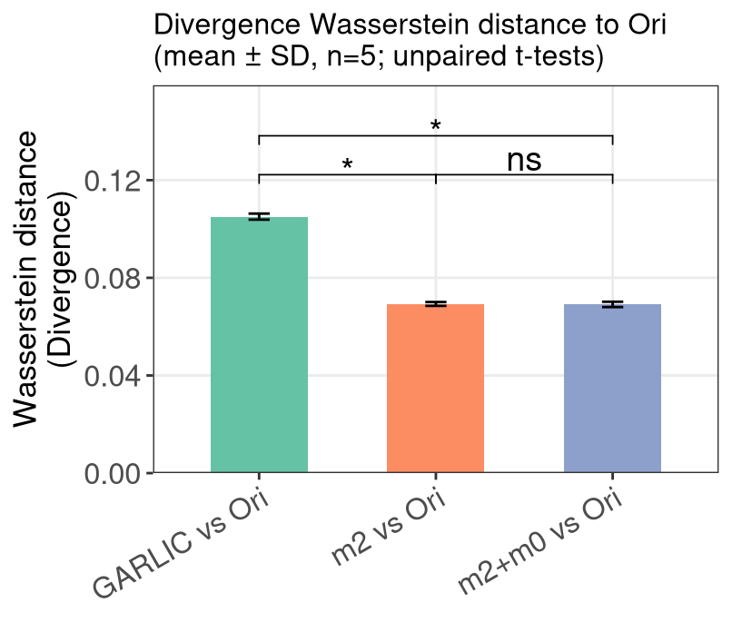

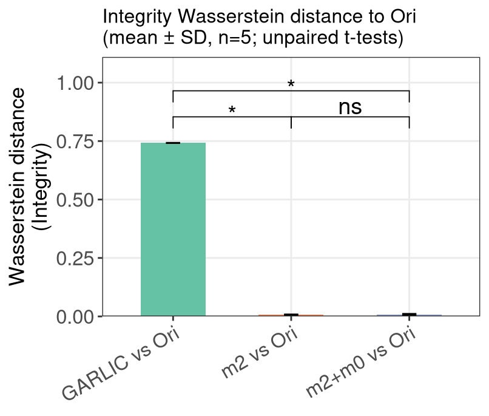

### 2.06 k-mer spectrum

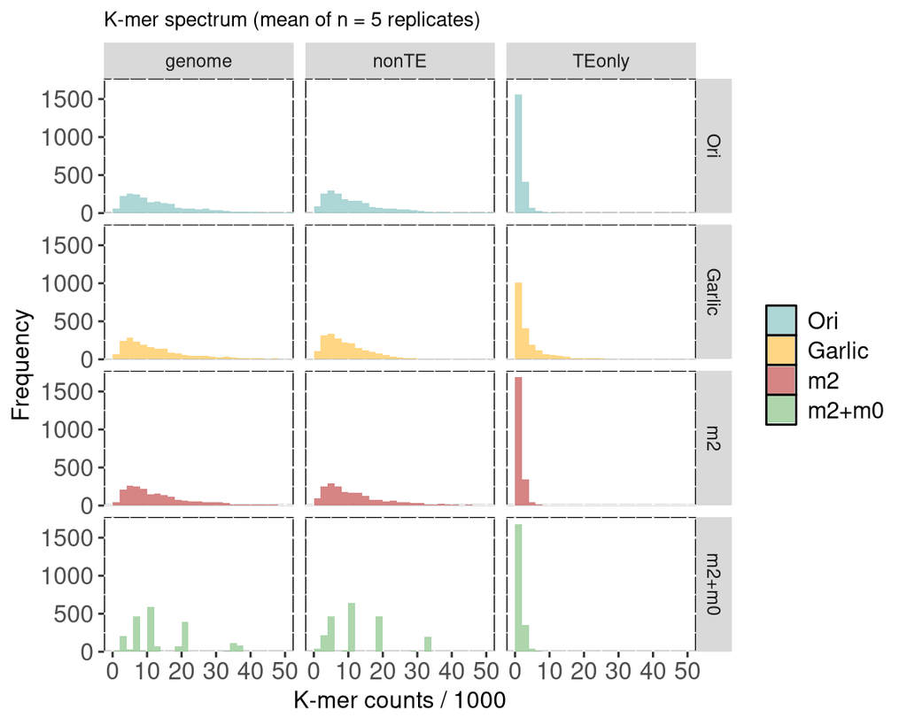

### 2.06a Jensen-Shannon divergence: k-mer spectrum (per replicate)

Canonical 6-mer count spectra (as in panel 2.06/Fig. 2G), compared per replicate for each of the three sequence categories (whole genome, non-TE, TE-only). Unlike the JSD/Wasserstein sections above, this only covers Comparison 2 (GARLIC/m2/m2+m0 vs Ori) - `item30_te_sim_eval_raw.sh` was never run for dnvTEe/TEGS (Comparison 1), so no k-mer data exists for that comparison. The k-mer vocabulary (2080 canonical 6-mers) is fixed and identical across all replicates/tools (same Python enumeration), so unlike the superfamily JSD, no union/zero-fill is needed - counts are matched by the `kmer` column via a join, as a safety check against any row-order difference between files. Reuses `jsd_divergence()` defined in section 2.03a.

| comparison | rep | category | jsd |
| --- | --- | --- | --- |
| GARLIC vs Ori | 1 | genome | 0.0071 |
| GARLIC vs Ori | 2 | genome | 0.0069 |
| GARLIC vs Ori | 3 | genome | 0.0052 |
| GARLIC vs Ori | 4 | genome | 0.0086 |
| GARLIC vs Ori | 5 | genome | 0.0072 |
| m2 vs Ori | 1 | genome | 0.0002 |
| m2 vs Ori | 2 | genome | 0.0002 |
| m2 vs Ori | 3 | genome | 0.0002 |
| m2 vs Ori | 4 | genome | 0.0002 |
| m2 vs Ori | 5 | genome | 0.0002 |
| m2+m0 vs Ori | 1 | genome | 0.0232 |
| m2+m0 vs Ori | 2 | genome | 0.0232 |
| m2+m0 vs Ori | 3 | genome | 0.0233 |
| m2+m0 vs Ori | 4 | genome | 0.0233 |
| m2+m0 vs Ori | 5 | genome | 0.0234 |
| GARLIC vs Ori | 1 | nonTE | 0.0102 |
| GARLIC vs Ori | 2 | nonTE | 0.0085 |
| GARLIC vs Ori | 3 | nonTE | 0.0097 |
| GARLIC vs Ori | 4 | nonTE | 0.0100 |
| GARLIC vs Ori | 5 | nonTE | 0.0089 |
| m2 vs Ori | 1 | nonTE | 0.0000 |
| m2 vs Ori | 2 | nonTE | 0.0000 |
| m2 vs Ori | 3 | nonTE | 0.0000 |
| m2 vs Ori | 4 | nonTE | 0.0000 |
| m2 vs Ori | 5 | nonTE | 0.0000 |
| m2+m0 vs Ori | 1 | nonTE | 0.0262 |
| m2+m0 vs Ori | 2 | nonTE | 0.0261 |
| m2+m0 vs Ori | 3 | nonTE | 0.0261 |
| m2+m0 vs Ori | 4 | nonTE | 0.0262 |
| m2+m0 vs Ori | 5 | nonTE | 0.0261 |
| GARLIC vs Ori | 1 | TEonly | 0.0680 |
| GARLIC vs Ori | 2 | TEonly | 0.0681 |
| GARLIC vs Ori | 3 | TEonly | 0.0609 |
| GARLIC vs Ori | 4 | TEonly | 0.0659 |
| GARLIC vs Ori | 5 | TEonly | 0.0681 |
| m2 vs Ori | 1 | TEonly | 0.0066 |
| m2 vs Ori | 2 | TEonly | 0.0058 |
| m2 vs Ori | 3 | TEonly | 0.0060 |
| m2 vs Ori | 4 | TEonly | 0.0057 |
| m2 vs Ori | 5 | TEonly | 0.0061 |
| m2+m0 vs Ori | 1 | TEonly | 0.0058 |
| m2+m0 vs Ori | 2 | TEonly | 0.0063 |
| m2+m0 vs Ori | 3 | TEonly | 0.0058 |
| m2+m0 vs Ori | 4 | TEonly | 0.0060 |
| m2+m0 vs Ori | 5 | TEonly | 0.0063 |

File saved as: jsd_kmer_spectrum_per_replicate.tsv (columns: comparison, rep, category [“genome”/“nonTE”/“TEonly”], jsd)

### 2.06b k-mer spectrum JSD: mean ± SD and significance testing

Only the three GARLIC/m2/m2+m0-vs-Ori groups exist here (no dnvTEe/TEGS k-mer data, as noted in 2.06a), so there is no one-sample paired-difference test to run - all three comparisons are independent replicate sets, tested pairwise with unpaired (two-sample Welch) t-tests, same as the Garlic/m2/m2+m0 rows in 2.03b/2.05b. Reuses `tidy_ttest_dist()` from section 2.03b.

| comparison | category | n | mean_jsd | sd_jsd |
| --- | --- | --- | --- | --- |
| GARLIC vs Ori | TEonly | 5 | 0.0662 | 0.0031 |
| GARLIC vs Ori | genome | 5 | 0.0070 | 0.0012 |
| GARLIC vs Ori | nonTE | 5 | 0.0095 | 0.0007 |
| m2 vs Ori | TEonly | 5 | 0.0060 | 0.0003 |
| m2 vs Ori | genome | 5 | 0.0002 | 0.0000 |
| m2 vs Ori | nonTE | 5 | 0.0000 | 0.0000 |
| m2+m0 vs Ori | TEonly | 5 | 0.0061 | 0.0002 |
| m2+m0 vs Ori | genome | 5 | 0.0233 | 0.0001 |
| m2+m0 vs Ori | nonTE | 5 | 0.0261 | 0.0001 |

| comparison | test_type | n1 | n2 | mean1 | mean2 | reference | mean_diff | t_statistic | df | p_value | conf_low | conf_high | alternative | category | group1 | group2 |
| --- | --- | --- | --- | --- | --- | --- | --- | --- | --- | --- | --- | --- | --- | --- | --- | --- |
| GARLIC vs m2 (k-mer JSD, genome) | two-sample t-test (Welch, unpaired) | 5 | 5 | 0.0070 | 0.0002 | NA | 0.0068 | 12.3116 | 4.0005 | 0.0002 | 0.0053 | 0.0083 | two.sided | genome | GARLIC vs Ori | m2 vs Ori |
| GARLIC vs m2+m0 (k-mer JSD, genome) | two-sample t-test (Welch, unpaired) | 5 | 5 | 0.0070 | 0.0233 | NA | -0.0163 | -29.3837 | 4.0254 | 0.0000 | -0.0178 | -0.0147 | two.sided | genome | GARLIC vs Ori | m2+m0 vs Ori |
| m2 vs m2+m0 (k-mer JSD, genome) | two-sample t-test (Welch, unpaired) | 5 | 5 | 0.0002 | 0.0233 | NA | -0.0231 | -733.8627 | 4.1533 | 0.0000 | -0.0232 | -0.0230 | two.sided | genome | m2 vs Ori | m2+m0 vs Ori |
| GARLIC vs m2 (k-mer JSD, nonTE) | two-sample t-test (Welch, unpaired) | 5 | 5 | 0.0095 | 0.0000 | NA | 0.0095 | 29.0452 | 4.0000 | 0.0000 | 0.0086 | 0.0104 | two.sided | nonTE | GARLIC vs Ori | m2 vs Ori |
| GARLIC vs m2+m0 (k-mer JSD, nonTE) | two-sample t-test (Welch, unpaired) | 5 | 5 | 0.0095 | 0.0261 | NA | -0.0167 | -50.9679 | 4.0451 | 0.0000 | -0.0176 | -0.0158 | two.sided | nonTE | GARLIC vs Ori | m2+m0 vs Ori |
| m2 vs m2+m0 (k-mer JSD, nonTE) | two-sample t-test (Welch, unpaired) | 5 | 5 | 0.0000 | 0.0261 | NA | -0.0261 | -1067.3094 | 4.0000 | 0.0000 | -0.0262 | -0.0261 | two.sided | nonTE | m2 vs Ori | m2+m0 vs Ori |
| GARLIC vs m2 (k-mer JSD, TEonly) | two-sample t-test (Welch, unpaired) | 5 | 5 | 0.0662 | 0.0060 | NA | 0.0602 | 43.0064 | 4.0898 | 0.0000 | 0.0563 | 0.0640 | two.sided | TEonly | GARLIC vs Ori | m2 vs Ori |
| GARLIC vs m2+m0 (k-mer JSD, TEonly) | two-sample t-test (Welch, unpaired) | 5 | 5 | 0.0662 | 0.0061 | NA | 0.0602 | 43.1396 | 4.0370 | 0.0000 | 0.0563 | 0.0640 | two.sided | TEonly | GARLIC vs Ori | m2+m0 vs Ori |
| m2 vs m2+m0 (k-mer JSD, TEonly) | two-sample t-test (Welch, unpaired) | 5 | 5 | 0.0060 | 0.0061 | NA | 0.0000 | -0.0611 | 6.8198 | 0.9530 | -0.0004 | 0.0004 | two.sided | TEonly | m2 vs Ori | m2+m0 vs Ori |

Files saved as: jsd_kmer_meansd.tsv, jsd_kmer_ttest.tsv

### 2.06c k-mer spectrum JSD: bar plots (mean ± SD, asterisk if p < 0.001)

Same layout as 2.03c/2.05c, but only the 3-bar GARLIC/m2/m2+m0-vs-Ori style applies here (no dnvTEe/TEGS k-mer data), so there’s one plot per sequence category instead of a separate one-sample plot. Reuses `sig_asterisk()` from 2.03c.

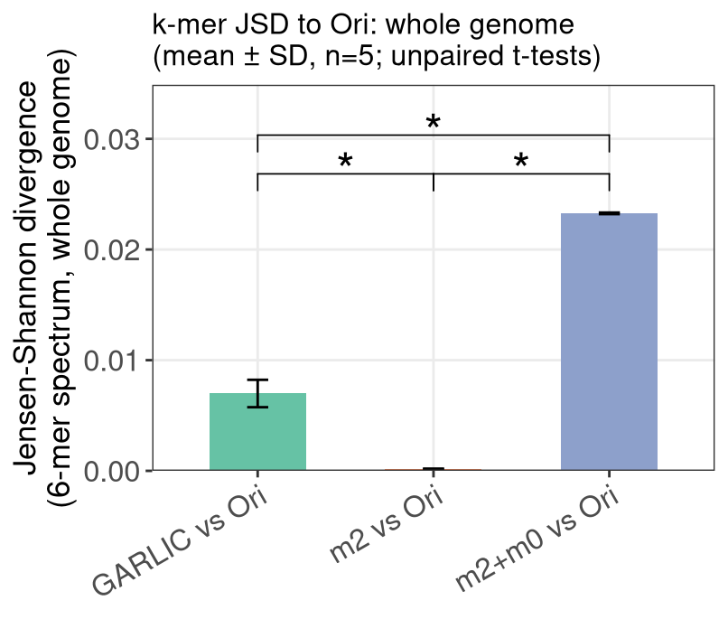

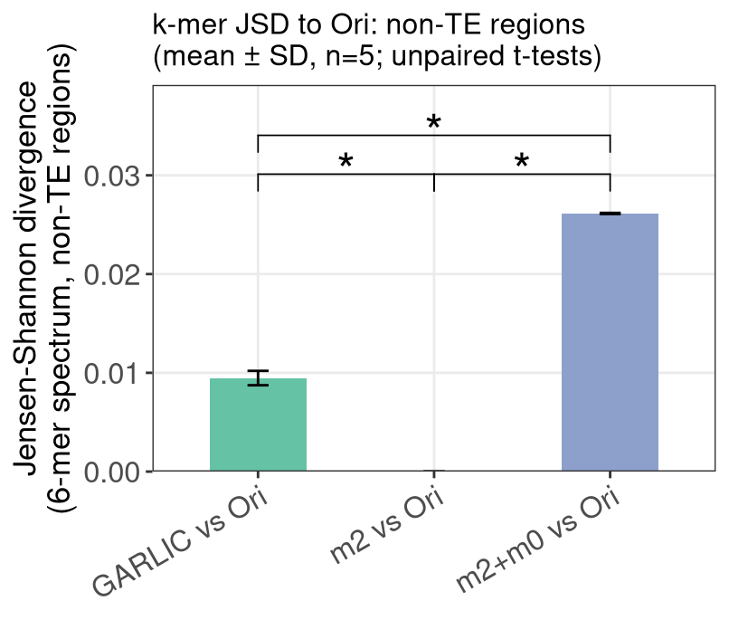

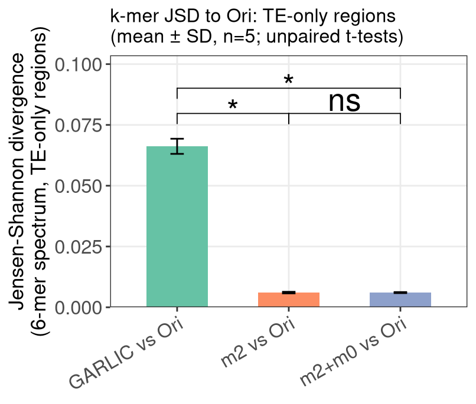

### 2.07 entropy

Shannon entropy in sliding 1-kb windows along each sequence category (whole genome, non-TE, TE-only). Ori is a single genome; GARLIC/m2/m2+m0 have one set of tables per replicate. Window positions do not line up across replicates (each replicate has a different total length, and the non-TE/TE-only sequences are concatenations), so entropy cannot be averaged window-by-window; the plots below show replicate 1, and the replicate-level comparison is done on whole entropy distributions in 2.07a-c.

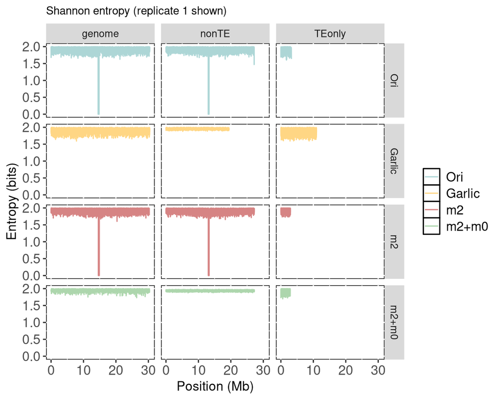

#### Supplementary: entropy along the sequence, all 5 replicates per simulator

Files saved as: entropy_spectrum_allreps_Garlic.png, entropy_spectrum_allreps_m2.png, entropy_spectrum_allreps_m2m0.png

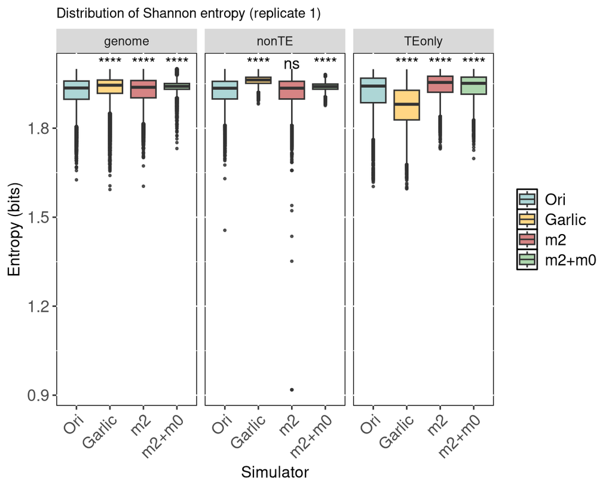

#### Check: does replicate 1 represent all 5 replicates?

The same window-level Wilcoxon test vs Ori as in the boxplot above, run on each replicate separately. `signif_labels` lists the distinct star labels across the 5 replicates (same cut-offs as `stat_compare_means`); a single label means every replicate gives the same result as replicate 1. These p-values are descriptive only: windows (~3,000-30,000 per test) are not independent, so even tiny shifts in entropy reach significance - the replicate-level test is in 2.07b.

| Category | simulator | n_reps | median_entropy_min | median_entropy_max | p_min | p_max | signif_labels | median_entropy_ori |
| --- | --- | --- | --- | --- | --- | --- | --- | --- |
| TEonly | Garlic | 5 | 1.8760 | 1.8846 | 4.2e-264 | 6.5e-186 | **** | 1.9421 |
| TEonly | m2 | 5 | 1.9507 | 1.9543 | 7.8e-37 | 8.5e-22 | **** | 1.9421 |
| TEonly | m2+m0 | 5 | 1.9513 | 1.9533 | 1.6e-32 | 4.0e-22 | **** | 1.9421 |
| genome | Garlic | 5 | 1.9385 | 1.9521 | 0.0e+00 | 5.7e-11 | **** | 1.9356 |
| genome | m2 | 5 | 1.9377 | 1.9382 | 8.6e-19 | 1.7e-14 | **** | 1.9356 |
| genome | m2+m0 | 5 | 1.9410 | 1.9412 | 8.3e-183 | 1.1e-176 | **** | 1.9356 |
| nonTE | Garlic | 5 | 1.9611 | 1.9625 | 0.0e+00 | 0.0e+00 | **** | 1.9348 |
| nonTE | m2 | 5 | 1.9349 | 1.9353 | 5.8e-01 | 7.8e-01 | ns | 1.9348 |
| nonTE | m2+m0 | 5 | 1.9403 | 1.9404 | 1.0e-123 | 5.7e-120 | **** | 1.9348 |

Files saved as: entropy_wilcox_per_replicate.tsv, entropy_wilcox_per_replicate_summary.tsv

### 2.07a Wasserstein distance: window entropy (per replicate)

1D Wasserstein distance between each replicate’s window-entropy distribution and Ori’s, per sequence category, with zero-entropy (N-run) windows excluded. Same “single fixed Ori reference” design as the GARLIC/m2/m2+m0 rows in 2.05a. Reuses `wasserstein1d()` and `wasserstein_between_reps()` from 2.05a; the `metric` column holds the sequence category (genome/nonTE/TEonly), as it holds div/itg there.

| comparison | rep | metric | wasserstein |
| --- | --- | --- | --- |
| GARLIC vs Ori | 1 | genome | 0.0098 |
| GARLIC vs Ori | 2 | genome | 0.0086 |
| GARLIC vs Ori | 3 | genome | 0.0178 |
| GARLIC vs Ori | 4 | genome | 0.0044 |
| GARLIC vs Ori | 5 | genome | 0.0099 |
| m2 vs Ori | 1 | genome | 0.0041 |
| m2 vs Ori | 2 | genome | 0.0042 |
| m2 vs Ori | 3 | genome | 0.0040 |
| m2 vs Ori | 4 | genome | 0.0038 |
| m2 vs Ori | 5 | genome | 0.0040 |
| m2+m0 vs Ori | 1 | genome | 0.0237 |
| m2+m0 vs Ori | 2 | genome | 0.0236 |
| m2+m0 vs Ori | 3 | genome | 0.0238 |
| m2+m0 vs Ori | 4 | genome | 0.0237 |
| m2+m0 vs Ori | 5 | genome | 0.0238 |
| GARLIC vs Ori | 1 | nonTE | 0.0358 |
| GARLIC vs Ori | 2 | nonTE | 0.0328 |
| GARLIC vs Ori | 3 | nonTE | 0.0348 |
| GARLIC vs Ori | 4 | nonTE | 0.0354 |
| GARLIC vs Ori | 5 | nonTE | 0.0339 |
| m2 vs Ori | 1 | nonTE | 0.0004 |
| m2 vs Ori | 2 | nonTE | 0.0004 |
| m2 vs Ori | 3 | nonTE | 0.0004 |
| m2 vs Ori | 4 | nonTE | 0.0003 |
| m2 vs Ori | 5 | nonTE | 0.0006 |
| m2+m0 vs Ori | 1 | nonTE | 0.0243 |
| m2+m0 vs Ori | 2 | nonTE | 0.0244 |
| m2+m0 vs Ori | 3 | nonTE | 0.0243 |
| m2+m0 vs Ori | 4 | nonTE | 0.0244 |
| m2+m0 vs Ori | 5 | nonTE | 0.0244 |
| GARLIC vs Ori | 1 | TEonly | 0.0414 |
| GARLIC vs Ori | 2 | TEonly | 0.0433 |
| GARLIC vs Ori | 3 | TEonly | 0.0378 |
| GARLIC vs Ori | 4 | TEonly | 0.0439 |
| GARLIC vs Ori | 5 | TEonly | 0.0403 |
| m2 vs Ori | 1 | TEonly | 0.0279 |
| m2 vs Ori | 2 | TEonly | 0.0247 |
| m2 vs Ori | 3 | TEonly | 0.0268 |
| m2 vs Ori | 4 | TEonly | 0.0249 |
| m2 vs Ori | 5 | TEonly | 0.0255 |
| m2+m0 vs Ori | 1 | TEonly | 0.0250 |
| m2+m0 vs Ori | 2 | TEonly | 0.0270 |
| m2+m0 vs Ori | 3 | TEonly | 0.0251 |
| m2+m0 vs Ori | 4 | TEonly | 0.0262 |
| m2+m0 vs Ori | 5 | TEonly | 0.0267 |

File saved as: wasserstein_entropy_per_replicate.tsv (columns: comparison, rep, metric [“genome”/“nonTE”/“TEonly”], wasserstein)

### 2.07b Entropy Wasserstein distance: mean ± SD and significance testing

GARLIC/m2/m2+m0 replicates were generated independently, so their distance-to-Ori values are compared pairwise with unpaired (two-sample Welch) t-tests, as in 2.05b. Reuses `tidy_ttest_dist()` from 2.03b.

| comparison | metric | n | mean_wasserstein | sd_wasserstein |
| --- | --- | --- | --- | --- |
| GARLIC vs Ori | TEonly | 5 | 0.0413 | 0.0024 |
| GARLIC vs Ori | genome | 5 | 0.0101 | 0.0049 |
| GARLIC vs Ori | nonTE | 5 | 0.0345 | 0.0012 |
| m2 vs Ori | TEonly | 5 | 0.0259 | 0.0013 |
| m2 vs Ori | genome | 5 | 0.0040 | 0.0001 |
| m2 vs Ori | nonTE | 5 | 0.0004 | 0.0001 |
| m2+m0 vs Ori | TEonly | 5 | 0.0260 | 0.0009 |
| m2+m0 vs Ori | genome | 5 | 0.0237 | 0.0001 |
| m2+m0 vs Ori | nonTE | 5 | 0.0244 | 0.0000 |

| comparison | test_type | n1 | n2 | mean1 | mean2 | reference | mean_diff | t_statistic | df | p_value | conf_low | conf_high | alternative | metric | group1 | group2 |
| --- | --- | --- | --- | --- | --- | --- | --- | --- | --- | --- | --- | --- | --- | --- | --- | --- |
| GARLIC vs m2 (distance-to-Ori entropy Wasserstein, genome) | two-sample t-test (Welch, unpaired) | 5 | 5 | 0.0101 | 0.0040 | NA | 0.0061 | 2.7898 | 4.0056 | 0.0492 | 0.0000 | 0.0121 | two.sided | genome | GARLIC vs Ori | m2 vs Ori |
| GARLIC vs m2+m0 (distance-to-Ori entropy Wasserstein, genome) | two-sample t-test (Welch, unpaired) | 5 | 5 | 0.0101 | 0.0237 | NA | -0.0136 | -6.2806 | 4.0021 | 0.0033 | -0.0197 | -0.0076 | two.sided | genome | GARLIC vs Ori | m2+m0 vs Ori |
| m2 vs m2+m0 (distance-to-Ori entropy Wasserstein, genome) | two-sample t-test (Welch, unpaired) | 5 | 5 | 0.0040 | 0.0237 | NA | -0.0197 | -292.0951 | 6.6405 | 0.0000 | -0.0199 | -0.0195 | two.sided | genome | m2 vs Ori | m2+m0 vs Ori |
| GARLIC vs m2 (distance-to-Ori entropy Wasserstein, nonTE) | two-sample t-test (Welch, unpaired) | 5 | 5 | 0.0345 | 0.0004 | NA | 0.0341 | 62.6083 | 4.0503 | 0.0000 | 0.0326 | 0.0356 | two.sided | nonTE | GARLIC vs Ori | m2 vs Ori |
| GARLIC vs m2+m0 (distance-to-Ori entropy Wasserstein, nonTE) | two-sample t-test (Welch, unpaired) | 5 | 5 | 0.0345 | 0.0244 | NA | 0.0102 | 18.7128 | 4.0026 | 0.0000 | 0.0087 | 0.0117 | two.sided | nonTE | GARLIC vs Ori | m2+m0 vs Ori |
| m2 vs m2+m0 (distance-to-Ori entropy Wasserstein, nonTE) | two-sample t-test (Welch, unpaired) | 5 | 5 | 0.0004 | 0.0244 | NA | -0.0240 | -541.9550 | 4.4133 | 0.0000 | -0.0241 | -0.0238 | two.sided | nonTE | m2 vs Ori | m2+m0 vs Ori |
| GARLIC vs m2 (distance-to-Ori entropy Wasserstein, TEonly) | two-sample t-test (Welch, unpaired) | 5 | 5 | 0.0413 | 0.0259 | NA | 0.0154 | 12.3202 | 6.2322 | 0.0000 | 0.0124 | 0.0184 | two.sided | TEonly | GARLIC vs Ori | m2 vs Ori |
| GARLIC vs m2+m0 (distance-to-Ori entropy Wasserstein, TEonly) | two-sample t-test (Welch, unpaired) | 5 | 5 | 0.0413 | 0.0260 | NA | 0.0153 | 13.1593 | 5.0879 | 0.0000 | 0.0124 | 0.0183 | two.sided | TEonly | GARLIC vs Ori | m2+m0 vs Ori |
| m2 vs m2+m0 (distance-to-Ori entropy Wasserstein, TEonly) | two-sample t-test (Welch, unpaired) | 5 | 5 | 0.0259 | 0.0260 | NA | 0.0000 | -0.0486 | 7.0133 | 0.9626 | -0.0018 | 0.0017 | two.sided | TEonly | m2 vs Ori | m2+m0 vs Ori |

Files saved as: wasserstein_entropy_meansd.tsv, wasserstein_entropy_ttest.tsv

### 2.07c Entropy Wasserstein distance: bar plots (mean ± SD, asterisk if p < 0.001)

Same layout as the GARLIC/m2/m2+m0-vs-Ori plots in 2.05c, one per sequence category. Reuses `plot_wasserstein_ori_bars()` from 2.05c with the entropy tables.

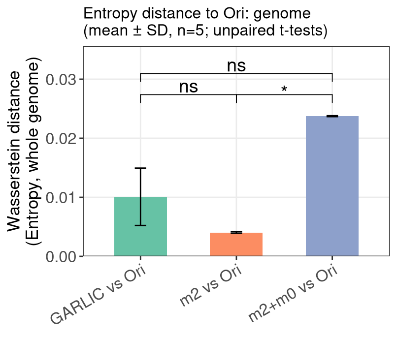

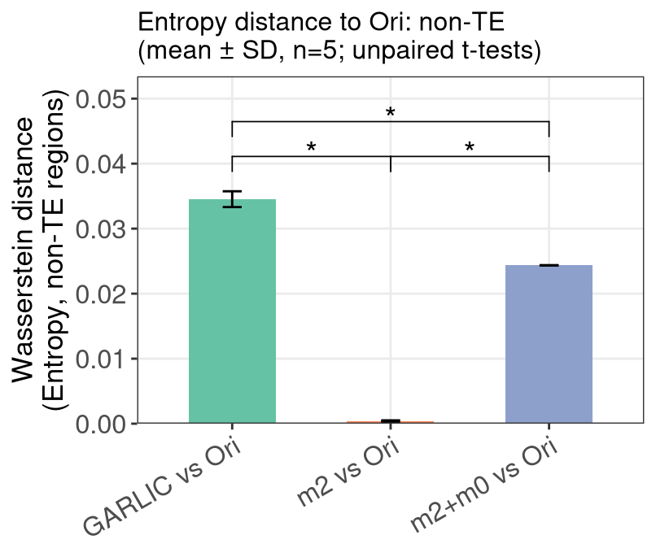

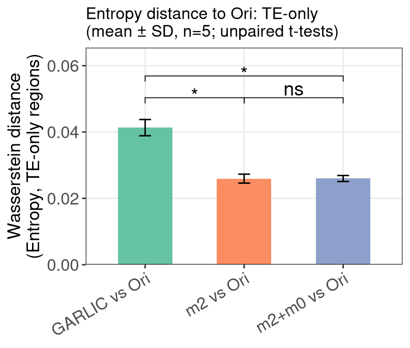